# TRABAJO FINAL COVID-19 DATASET

Lo primero que hacemos es establecer una relación del espacio de google collab con google drive, lugar donde tenemos las imagenes almacenadas.

```python
from google.colab import drive
drive.mount('/content/drive')
```

Importamos las librerías necesarias

```python
import tensorflow as tf
import numpy as np
import os
from matplotlib import pyplot as plt
from keras.preprocessing import image
from tensorflow.keras.preprocessing.image import ImageDataGenerator
```

Comprobamos que las fotos de han subido de manera correcta con una foto aleatoria introduciendo la ruta.

```python
img = image.load_img("/content/drive/MyDrive/TRABAJO FINAL COVID19 IA/test/Covid/0100.jpeg")
```

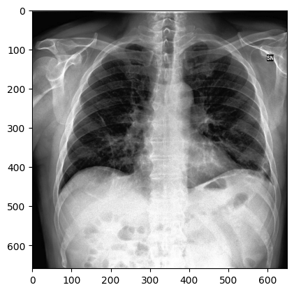

```python
plt.imshow(img)
```

```python
train = ImageDataGenerator(rescale=1/255)
test = ImageDataGenerator(rescale=1/255)
```

```python
train_dataset = train.flow_from_directory("/content/drive/MyDrive/TRABAJO FINAL COVID19 IA/train",
                                          target_size = (224, 224),
                                          batch_size = 10)

test_dataset = test.flow_from_directory("/content/drive/MyDrive/TRABAJO FINAL COVID19 IA/test",
                                          target_size= (224, 224),
                                          batch_size = 10 )
```

```
Found 251 images belonging to 3 classes.
Found 66 images belonging to 3 classes.
```

Dentro de train y test tenemos las siguientes 3 clases que son las que nos interesa clasificar y predecir.

```python
train_dataset.class_indices
```

```
{'Covid': 0, 'Neumonia': 1, 'Normal': 2}
```

```python
train_dataset.classes
```

```
array([0, 0, 0, 0, 0, 0, 0, 0, 0, 0, 0, 0, 0, 0, 0, 0, 0, 0, 0, 0, 0, 0,
       0, 0, 0, 0, 0, 0, 0, 0, 0, 0, 0, 0, 0, 0, 0, 0, 0, 0, 0, 0, 0, 0,
       0, 0, 0, 0, 0, 0, 0, 0, 0, 0, 0, 0, 0, 0, 0, 0, 0, 0, 0, 0, 0, 0,
       0, 0, 0, 0, 0, 0, 0, 0, 0, 0, 0, 0, 0, 0, 0, 0, 0, 0, 0, 0, 0, 0,
       0, 0, 0, 0, 0, 0, 0, 0, 0, 0, 0, 0, 0, 0, 0, 0, 0, 0, 0, 0, 0, 0,
       0, 1, 1, 1, 1, 1, 1, 1, 1, 1, 1, 1, 1, 1, 1, 1, 1, 1, 1, 1, 1, 1,
       1, 1, 1, 1, 1, 1, 1, 1, 1, 1, 1, 1, 1, 1, 1, 1, 1, 1, 1, 1, 1, 1,
       1, 1, 1, 1, 1, 1, 1, 1, 1, 1, 1, 1, 1, 1, 1, 1, 1, 1, 1, 1, 1, 1,
       1, 1, 1, 1, 1, 2, 2, 2, 2, 2, 2, 2, 2, 2, 2, 2, 2, 2, 2, 2, 2, 2,
       2, 2, 2, 2, 2, 2, 2, 2, 2, 2, 2, 2, 2, 2, 2, 2, 2, 2, 2, 2, 2, 2,
       2, 2, 2, 2, 2, 2, 2, 2, 2, 2, 2, 2, 2, 2, 2, 2, 2, 2, 2, 2, 2, 2,
       2, 2, 2, 2, 2, 2, 2, 2, 2], dtype=int32)
```

```python
test_dataset.classes
```

```
array([0, 0, 0, 0, 0, 0, 0, 0, 0, 0, 0, 0, 0, 0, 0, 0, 0, 0, 0, 0, 0, 0,
       0, 0, 0, 0, 1, 1, 1, 1, 1, 1, 1, 1, 1, 1, 1, 1, 1, 1, 1, 1, 1, 1,
       1, 1, 2, 2, 2, 2, 2, 2, 2, 2, 2, 2, 2, 2, 2, 2, 2, 2, 2, 2, 2, 2],
      dtype=int32)
```

Usamos para entrenar al modelo la red convolucional ya existente llamada VGG16

```python
import tensorflow as tf
from tensorflow.keras.applications import VGG16
from tensorflow.keras.models import Sequential
from tensorflow.keras.layers import Dense, Flatten

# Cargar el modelo VGG16 preentrenado (incluyendo las capas densas al final)
vgg16_model = VGG16(weights='imagenet', include_top=False, input_shape=(224, 224, 3))

# Congelar las capas preentrenadas
for layer in vgg16_model.layers:
    layer.trainable = False

# Crear un nuevo modelo secuencial y agregar las capas de VGG16
model = Sequential()
model.add(vgg16_model)

# Añadir capas densas personalizadas para la clasificación
model.add(Flatten())
model.add(Dense(4096, activation='relu'))
model.add(Dense(4096, activation='relu'))
model.add(Dense(3, activation='softmax'))  # 3 porque tenemos 3 clases
```

```python
# Compilar el modelo
model.compile(optimizer='adam', loss='categorical_crossentropy', metrics=['accuracy'])

# Visualizar la arquitectura del modelo
model.summary()
```

```
Model: "sequential_2"
_________________________________________________________________
 Layer (type)                Output Shape              Param #
=================================================================
 vgg16 (Functional)          (None, 7, 7, 512)         14714688

 flatten_2 (Flatten)         (None, 25088)             0

 dense_6 (Dense)             (None, 4096)              102764544

 dense_7 (Dense)             (None, 4096)              16781312

 dense_8 (Dense)             (None, 3)                 12291

=================================================================
Total params: 134272835 (512.21 MB)
Trainable params: 119558147 (456.08 MB)
Non-trainable params: 14714688 (56.13 MB)
_________________________________________________________________
```

Pasamos nuestros datos de entrenamiento al modelo

```python
entrenamiento = model.fit(train_dataset, epochs=30, validation_data=test_dataset)
```

Se puede observar que hemos usado un número total de 30 épocas. Esto lo hacemos porque el valor de la pÉrdida y del accuracy se estacan queriendo decir que esta no puede variar o crecer más, aunque añadamos una mayor cantidad de épocas.

#### GRAFICAMOS Y CALCULAMOS MÉTRICAS DE GRAN IMPORTANCIA PARA EVALUAR LA FIABILIDAD DEL MODELO GENERADO

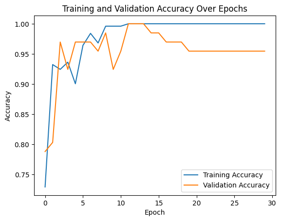

```python
plt.plot(entrenamiento.history['accuracy'], label='Training Accuracy')
plt.plot(entrenamiento.history['val_accuracy'], label='Validation Accuracy')
plt.xlabel('Epoch')
plt.ylabel('Accuracy')
plt.title('Training and Validation Accuracy Over Epochs')
plt.legend()
plt.show()
```

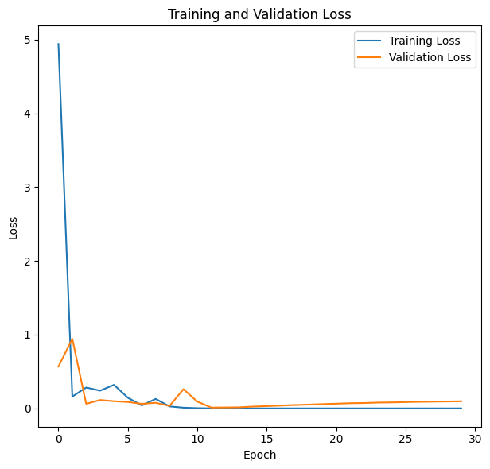

```python
# Obtener las pérdidas y precisión en el conjunto de entrenamiento y validación
train_loss = entrenamiento.history['loss']
train_acc = entrenamiento.history['accuracy']
val_loss = entrenamiento.history['val_loss']
val_acc = entrenamiento.history['val_accuracy']

# Graficar las pérdidas
plt.figure(figsize=(12, 6))

plt.subplot(1, 2, 1)
plt.plot(train_loss, label='Training Loss')
plt.plot(val_loss, label='Validation Loss')
plt.title('Training and Validation Loss')
plt.xlabel('Epoch')
plt.ylabel('Loss')
plt.legend()

plt.tight_layout()
plt.show()
```

```python
from sklearn.metrics import roc_auc_score

# Obtener predicciones del conjunto de entrenamiento y prueba
train_predictions = model.predict(train_dataset)
test_predictions = model.predict(test_dataset)

# Obtener etiquetas directamente de los generadores de datos
train_labels = train_dataset.labels
test_labels = test_dataset.labels

# Calcular el área bajo la curva ROC para el conjunto de entrenamiento y prueba
roc_auc_train = roc_auc_score(train_labels, train_predictions, multi_class='ovr')
roc_auc_test = roc_auc_score(test_labels, test_predictions, multi_class='ovr')

# Imprimir el área bajo la curva ROC para entrenamiento y prueba
print(f'AUC for Training: {roc_auc_train:.2f}')
print(f'AUC for Test: {roc_auc_test:.2f}')
```

```
AUC for Training: 0.55
AUC for Test: 0.51
```

Como no hemos podido graficar la curva ROC por ser un caso multiclase (solo se permite la representación de clases binarias), hemos sacado el valor de AUC para train y para test que nos dice el área de debajo de la curva ROC.

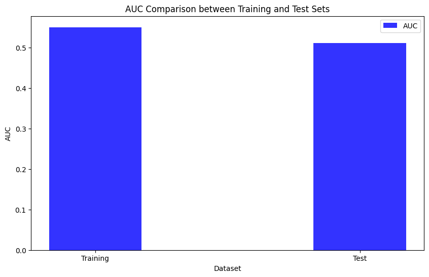

```python
# Graficar las métricas
plt.figure(figsize=(10, 6))
bar_width = 0.35
index = np.arange(2)
opacity = 0.8

plt.bar(index, [roc_auc_train, roc_auc_test], bar_width,
         alpha=opacity, color='b', label='AUC')

plt.xlabel('Dataset')
plt.ylabel('AUC')
plt.title('AUC Comparison between Training and Test Sets')
plt.xticks(index, ('Training', 'Test'))
plt.legend()

plt.show()
```

```python
from sklearn.metrics import accuracy_score, precision_score, recall_score, f1_score, confusion_matrix

# Función para imprimir y devolver métricas
def print_and_return_metrics(labels, predictions, prefix):
    accuracy = accuracy_score(labels, np.argmax(predictions, axis=1))
    precision = precision_score(labels, np.argmax(predictions, axis=1), average='weighted')
    recall = recall_score(labels, np.argmax(predictions, axis=1), average='weighted')
    f1 = f1_score(labels, np.argmax(predictions, axis=1), average='weighted')

    # Matriz de confusión
    confusion_mat = confusion_matrix(labels, np.argmax(predictions, axis=1))

    # Imprimir métricas
    print(f"{prefix} Accuracy: {accuracy:.4f}")
    print(f"{prefix} Precision: {precision:.4f}")
    print(f"{prefix} Recall: {recall:.4f}")
    print(f"{prefix} F1 Score: {f1:.4f}")
    print(f"{prefix} Confusion Matrix:\n{confusion_mat}")

    return accuracy, precision, recall, f1

# Calcular y mostrar métricas para el conjunto de entrenamiento
print("Metrics for Training Set:")
train_accuracy, train_precision, train_recall, train_f1 = print_and_return_metrics(train_labels, train_predictions, "Train")

# Calcular y mostrar métricas para el conjunto de prueba
print("\nMetrics for Test Set:")
test_accuracy, test_precision, test_recall, test_f1 = print_and_return_metrics(test_labels, test_predictions, "Test")
```

```
Metrics for Training Set:
Train Accuracy: 0.4064
Train Precision: 0.4064
Train Recall: 0.4064
Train F1 Score: 0.4064
Train Confusion Matrix:
[[52 29 30]
 [28 26 16]
 [31 15 24]]

Metrics for Test Set:
Test Accuracy: 0.3788
Test Precision: 0.3770
Test Recall: 0.3788
Test F1 Score: 0.3766
Test Confusion Matrix:
[[10 10  6]
 [ 6  9  5]
 [10  4  6]]
```

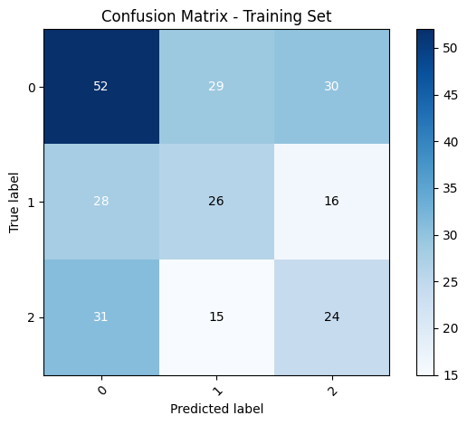

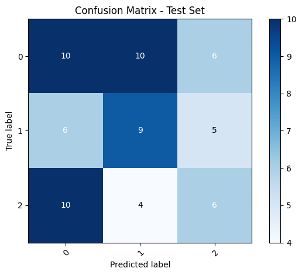

```python
import matplotlib.pyplot as plt
import seaborn as sns
from sklearn.metrics import confusion_matrix
from sklearn.utils.multiclass import unique_labels

def plot_confusion_matrix(y_true, y_pred, classes, title, cmap=plt.cm.Blues):
    cm = confusion_matrix(y_true, y_pred)
    classes = unique_labels(y_true, y_pred)

    fig, ax = plt.subplots()
    im = ax.imshow(cm, interpolation='nearest', cmap=cmap)
    ax.figure.colorbar(im, ax=ax)
    ax.set(xticks=np.arange(cm.shape[1]),
           yticks=np.arange(cm.shape[0]),
           xticklabels=classes, yticklabels=classes,
           title=title,
           ylabel='True label',
           xlabel='Predicted label')

    plt.setp(ax.get_xticklabels(), rotation=45, ha="right", rotation_mode="anchor")

    fmt = 'd'
    thresh = cm.max() / 2.
    for i in range(cm.shape[0]):
        for j in range(cm.shape[1]):
            ax.text(j, i, format(cm[i, j], fmt),
                    ha="center", va="center",
                    color="white" if cm[i, j] > thresh else "black")
    fig.tight_layout()
    plt.show()

# Usar la función para graficar la matriz de confusión del conjunto de entrenamiento
plot_confusion_matrix(train_labels, np.argmax(train_predictions, axis=1), classes=['covid', 'neumonia', 'normal'], title='Confusion Matrix - Training Set')

# Usar la función para graficar la matriz de confusión del conjunto de prueba
plot_confusion_matrix(test_labels, np.argmax(test_predictions, axis=1), classes=['covid', 'neumonia', 'normal'], title='Confusion Matrix - Test Set')
```

Ejecutamos un código que permita cargar una imagen desde cualquier ubicación del ordenador de tal forma que evitamos problemas de rutas. Tras esto predice con el modelo entrenado a qué clase pertence la imagen subida.

Hemos probado metiendo una foto de cada clase: covid, normal y neumonia. Podemos ver cómo para las tres ha clasificado de manera correcta.

Upload widget is only available when the cell has been executed in the current browser session. Please rerun this cell to enable.

```
Saving neumo.jpeg to neumo (3).jpeg
```

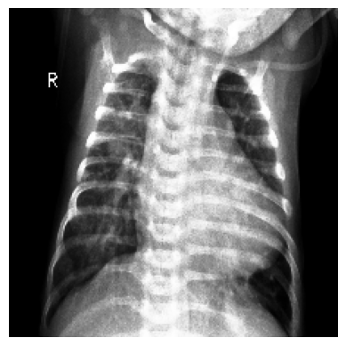

```
El resultado de la radiografía del paciente es: Neumonia
```

```python
from google.colab import files
from tensorflow.keras.preprocessing import image
from tensorflow.keras.applications.vgg16 import preprocess_input
import numpy as np
import matplotlib.pyplot as plt
from PIL import Image

# Diccionario invertido para obtener nombres de clases a partir de números
class_dict = {v: k for k, v in train_dataset.class_indices.items()}

# Función para cargar y preprocesar la imagen
def load_and_preprocess_image(img_path):
    # Cargar la imagen seleccionada
    img = image.load_img(img_path, target_size=(224, 224))

    # Convertir la imagen a un array numpy
    img_array = image.img_to_array(img)

    # Añadir una dimensión extra (batch size) y preprocesar la imagen
    img_array = np.expand_dims(img_array, axis=0)
    img_array = preprocess_input(img_array)

    return img, img_array

# Subir la imagen desde el sistema local
uploaded = files.upload()

# Extraer el nombre del archivo y la ruta
img_path = list(uploaded.keys())[0]

# Cargar y preprocesar la imagen
img, img_array = load_and_preprocess_image(img_path)

# Mostrar la imagen
plt.imshow(img)
plt.axis('off')
plt.show()

# Hacer la predicción utilizando tu modelo
prediction = model.predict(img_array)

# Obtener la clase predicha (como número)
predicted_class_number = np.argmax(prediction)

# Obtener el nombre de la clase a partir del número
predicted_class_name = class_dict[predicted_class_number]

# Imprimir la clase predicha (nombre)
print(f'El resultado de la radiografía del paciente es: {predicted_class_name}')
```

Upload widget is only available when the cell has been executed in the current browser session. Please rerun this cell to enable.

```
Saving normal.jpeg to normal (3).jpeg
```

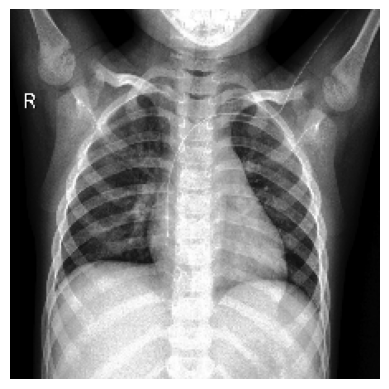

```
El resultado de la radiografía del paciente es: Normal
```

```python
# Subir la imagen desde el sistema local
uploaded = files.upload()

# Extraer el nombre del archivo y la ruta
img_path = list(uploaded.keys())[0]

# Cargar y preprocesar la imagen
img, img_array = load_and_preprocess_image(img_path)

# Mostrar la imagen
plt.imshow(img)
plt.axis('off')
plt.show()

# Hacer la predicción utilizando tu modelo
prediction = model.predict(img_array)

# Obtener la clase predicha (como número)
predicted_class_number = np.argmax(prediction)

# Obtener el nombre de la clase a partir del número
predicted_class_name = class_dict[predicted_class_number]

# Imprimir la clase predicha (nombre)
print(f'El resultado de la radiografía del paciente es: {predicted_class_name}')
```

Upload widget is only available when the cell has been executed in the current browser session. Please rerun this cell to enable.

```
Saving covid.jpg to covid (2).jpg
```

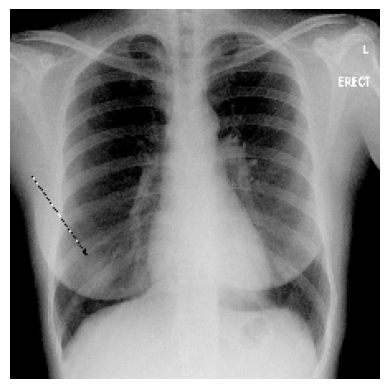

```
El resultado de la radiografía del paciente es: Covid
```

```python
# Subir la imagen desde el sistema local
uploaded = files.upload()

# Extraer el nombre del archivo y la ruta
img_path = list(uploaded.keys())[0]

# Cargar y preprocesar la imagen
img, img_array = load_and_preprocess_image(img_path)

# Mostrar la imagen
plt.imshow(img)
plt.axis('off')
plt.show()

# Hacer la predicción utilizando tu modelo
prediction = model.predict(img_array)

# Obtener la clase predicha (como número)
predicted_class_number = np.argmax(prediction)

# Obtener el nombre de la clase a partir del número
predicted_class_name = class_dict[predicted_class_number]

# Imprimir la clase predicha (nombre)
print(f'El resultado de la radiografía del paciente es: {predicted_class_name}')
```